# Series Temporales

Josep R.C.

5/13/2021

# Teoría

- Según su estabilidad en el tiempo las series pueden ser: Estacionarias o No estacionarias.
- Tendencias crecientes/decrecientes en el tiempo se dan cuando la los valores en lugar de fluctuar sobre la un valor van aumentando/disminuyendo. La tendencia es estable si el pendiente de está se mantiene constante.

### Grafico QQ plot

- Qunatile-Quantile
- Define la distribución del conjunto de datos.

## Notebooks(PY) & Scripts(R)

1. **Section 3**:
- [Notebook 1](https://colab.research.google.com/github/Josep-at-work/curso-series-temporales/blob/master/1.%20Introduccion%20a%20las%20series%20temporales/Python/1_Python_Introducci%C3%B3n_a_las_series_temporales.ipynb)
- First plots, lineplot and QQplot.
2. **Section 4**:
- **Python**
  - [Notebook 2](https://colab.research.google.com/github/Josep-at-work/curso-series-temporales/blob/master/2.%20Serie%20temporal%20en%20R%20y%20Python/Python/2_Python_Objeto_serie_temporal.ipynb#scrollTo=xZYrVdyhe-w9)
  - Correct datatypes(datetime)
  - **Fecha como indice**, necesario para describir periodos de tiempo, para trabajar con series temporales
  - Definir **Frecuencia persistente**
  - **Missing values**
  - **Simplificación del dataset**. Basicamente eliminación de todas las métricas que no usamos en el momento y nos quedamos con solo un campo.
  - **Splitting data, train/test** para aplicar modelos de predicción más adelante.
- **R**
  - **Tiempo y Fecha**, POSIXt, lubridate y más -> Script 1
  - **Trabajando con Objectos de serie temporal** -> Script 2
  - **Objetos de series temporales (ts)** -> S2
  - **Valores faltantes y outliers** *forecats*, *zoo* -> S2
  - **Objetos ts Vs zoo** -> Script 3
    - En resumen las librerias buenas son lubridate para dar el formato de datetime, zoo para tratar el objeto de serie de tiempo y dygraph más estética para los plots. Zoo va bien para qualquier tipo de frecuencia mientras que ts es solo para frecuencia menusal trimestral o anual.
    - Ojo al formato de los datos!!
      - Con lubridate no da problemas: `mdy_hms(vibration$datetime)`
      - Con strptime surgen NA’s: `strptime(telemetry$datetime, format = "%d/%m/%Y %I:%M:%S %p")`
3. **Section 5**:
- **Ruido Blanco**(WN): Serie temporal donde los datos no siguen ningún patrón.
  - No Patron -> Futuro no predecible
  - Características: **Media**$\mu$ y **Varianza** $\sigma^2$ **constante**, y no tener autocorrelaciones.
  - **Autocorrelación** se mide através de la correlació entre los valores en el período *t* y los valores en tiempos pasados ie. $corr(x_t, x_{t-1})$.
  - Comportamiento de los datos aleatorio.
  - Notebook 3
    - Se crea ruido blanco y se compara este con la vibración de M1.
- **Random Walk**: Serie temporal donde los valores tienden a persistir en el tiempo y las diferencias entre períodos son simplemente ruido blanco.
  - $x_t = x_{t-1} + \epsilon_t$, $\epsilon_t = WN(\mu, \sigma^2)$

Generación de ruido blanco en R:

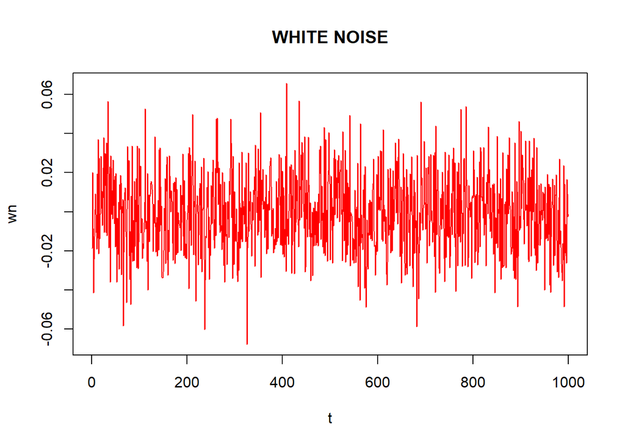

```r
WN <- function(N, mu, variance) {
  x<-rnorm(n=N, mean=mu,
                  sd=sqrt(variance))

  return(x)
}

wn<-WN(1000,0,0.0004)

plot(wn, main="WHITE NOISE",
     xlab="t",
     typ='l', col="red")
```